# Air Quality in Mainland China

Andi Liao

### Introduction to AQI

Air Quality Index (AQI) is used to show how polluted the air is in the local area. The AQI level in mainland China is based on the level of six atmospheric pollutants, SO2, NO2, PM10, PM2.5, CO and O3. AQI scores distributed from 0 to infinity, and the higher AQI indicates more polluted air. AQI = 100 is the cutoff for good air and lightly polluted air; AQI = 200 is the cutoff for moderately polluted air and heavily polluted air. More details can be found via: https://en.wikipedia.org/wiki/Air_quality_index.

### Overall Distrbution of Air Pollution in Maindland China

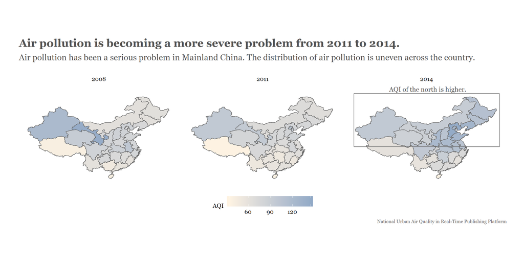

```r
ann_text <- data.frame(
                       x = 90,
                       y = 60,
                       lab = "Text",
                       year = factor(2014, levels = c("2008", "2011", "2014")))

g0 <-
      merged_data %>%
      ggplot() +
      geom_sf(
              aes(fill = value),
              color = "#696969") +
      geom_text(
                data = ann_text,
                aes(x = 105,
                    y = 57,
                    label = "AQI of the north is higher."),
                family = "Georgia",
                color = "#525252") +
      geom_rect(
                data = ann_text,
                aes(xmin = 73, xmax = 136, ymin = 32, ymax = 55),
                color = "#696969",
                size = 0.5,
                fill = "transparent") +
      scale_fill_continuous(
                            low = "#FEF3E2",
                            high = "#92AAC7",
                            limits = c(34, 145),
                            breaks = c(34, 60, 90, 120, 145),
                            labels = c("", "60", "90", "120", "")) +
      facet_grid(
                cols = vars(year)) +
      theme_cord() +
      theme(
          legend.key.width = unit(1, "cm")) +
      labs(
          title = wrapper("Air pollution is becoming a more severe problem from 2011 to 2014.", width = 120),
          subtitle = wrapper("Air pollution has been a serious problem in Mainland China. The distribution of air pollution is uneven across the country.", width = 135),
          caption = "National Urban Air Quality in Real-Time Publishing Platform",
          x = "Longtitude",
          y = "Latitude",
          fill = "AQI")

g0
```

### Factors Contributing to Air Pollution

#### Sulfur Dioxide and Smoke

The major source of air pollutants in China is sulfur dioxide emitted from factories, because the energy structure is currently dominated by coal. The central government has released a series of policies to control the emissions of sulfur dioxide. Although AQI is not the best indicator of sulfur dioxide pollution, areas highly polluted by sulfur dioxide usually suffer from other air pollutants as well. Similiar illustration can be applied to smoke as well.

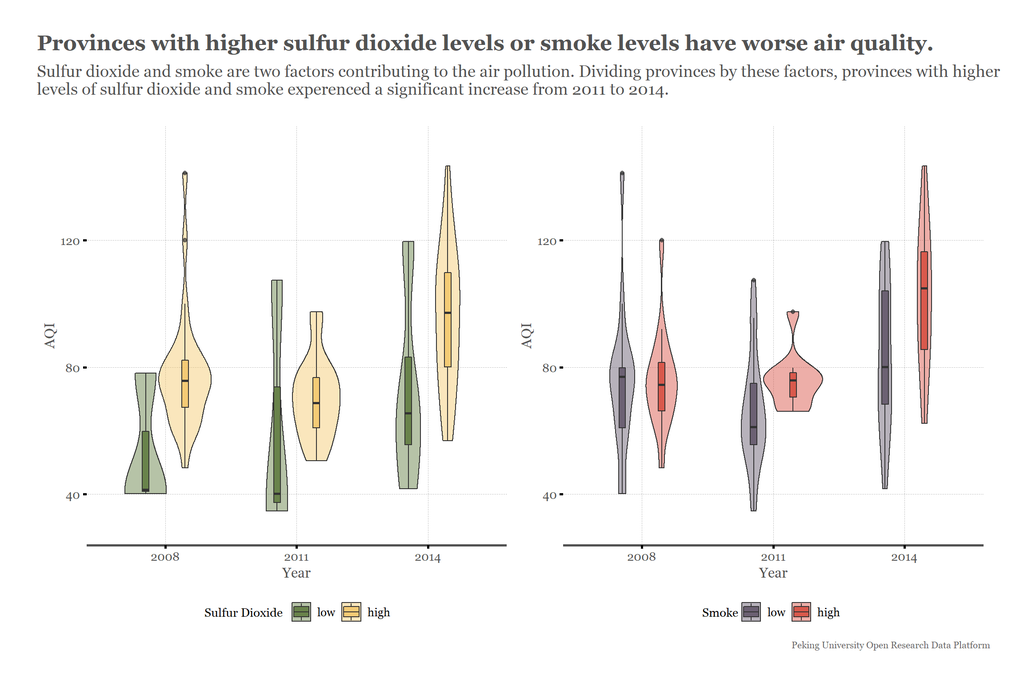

```r
g11 <-
      data_long %>%
      select(-("metrics")) %>%
      filter(measurement == "aqi" | measurement == "sulfur") %>%
      spread(measurement, value) %>%
      mutate(category = cut(sulfur, breaks = c(0, 70, Inf),
                            labels = c("low", "high"))) %>%
      group_by(category) %>%

      ggplot(
             aes(x = year,
                 y = aqi,
                 fill = category)) +
      scale_fill_manual(values =  c("#486824", "#F2C057")) +
      geom_violin(
                  position = position_dodge(width = 0.6),
                  width = 0.8,
                  alpha = 0.4) +
      geom_boxplot(
                   position = position_dodge(width = 0.6),
                   width = 0.1,
                   alpha = 0.7) +
      ylim(30, 150) +
      theme_new() +
      theme(
            plot.margin = unit(c(0.2, 0.2, 0.2, 0.2), "cm")) +
      labs(
            x = "Year",
            y = "AQI",
            fill = "Sulfur Dioxide")


g12 <-
      data_long %>%
      select(-("metrics")) %>%
      filter(measurement == "aqi" | measurement == "smoke") %>%
      spread(measurement, value) %>%
      mutate(category = cut(smoke, breaks = c(0, 100, Inf),
                            labels = c("low", "high"))) %>%
      group_by(category) %>%

      ggplot(aes(x = year, y = aqi, fill = category)) +
      scale_fill_manual(values =  c("#4C3F54", "#D13525")) +
      geom_violin(
                  position = position_dodge(width = 0.6),
                  width = 0.9,
                  alpha = 0.4) +
      geom_boxplot(
                   position = position_dodge(width = 0.6),
                   width = 0.1,
                   alpha = 0.7) +
      ylim(30, 150) +
      theme_new() +
      theme(
            plot.margin = unit(c(0.2, 0.2, 0.2, 0.2), "cm")) +
      labs(
            x = "Year",
            y = "AQI",
            fill = "Smoke")

g1 <-
      as.ggplot(plot_grid(g11, g12, ncol = 2)) +
      theme_new() +
      theme(
            axis.title = element_blank(),
            axis.line = element_blank(),
            axis.text = element_blank(),
            axis.ticks = element_blank(),
            panel.grid = element_blank()) +
      labs(
            title = wrapper("Provinces with higher sulfur dioxide levels or smoke levels have worse air quality.", width = 120),
            subtitle = wrapper("Sulfur dioxide and smoke are two factors contributing to the air pollution. Dividing provinces by these factors, provinces with higher levels of sulfur dioxide and smoke experenced a significant increase from 2011 to 2014.", width = 135),
            caption = "Peking University Open Research Data Platform")

g1
```

```r
p <-
  data_long %>%
  select(-("metrics")) %>%
  filter(measurement == "aqi") %>%
  spread(measurement, value) %>%
  group_by(region) %>%
  summarise(aqi = mean(aqi)) %>%
  rownames_to_column("province") %>%
  arrange(aqi) %>%
  mutate(region = factor(region, levels = .$region)) %>%
  mutate(is_south = south_prov)

g2 <-
  p %>%
  ggplot(aes(x = aqi, y = region)) +
  geom_segment(aes(x = 0, xend = aqi, y = region, yend = region, color = factor(is_south)), alpha = 0.9) +
  geom_point(aes(color = factor(is_south)), size = 1, alpha = 0.9) +
  scale_x_continuous(expand = c(0, 0), limits = c(0, 120)) +
  scale_y_discrete(limits = rev(levels(p$region))) +
  scale_color_manual(labels = c("No","Yes"), values = c("#92AAC7", "#EC96A4")) +
  theme_new() +
  theme(panel.grid.major.y = element_blank()) +
  labs(
      title = wrapper("Provinces in the southern part of China have better air quality.", width = 70),
      subtitle = wrapper("Calculate the average AQI grouped by province of year 2008, 2011 and 2014, and the ordered result shows that most southern provinces have lower average AQI. The only exception is Tibet, the plateau area in the western part.", width = 90),
      caption = "Peking University Open Research Data Platform",
      x = "Air Quality Index",
      y = "Province",
      color = "Southern Part")

g2
```

[output not shown]

#### Forest Coverage and Population

Population doesn’t affect the air quality much, but the forest coverage rate does. Interestingly, provinces with worse air quality all have relatively less forest coverage, but their population vary from low to high. The natural environment factor plays a key role in the air quality.

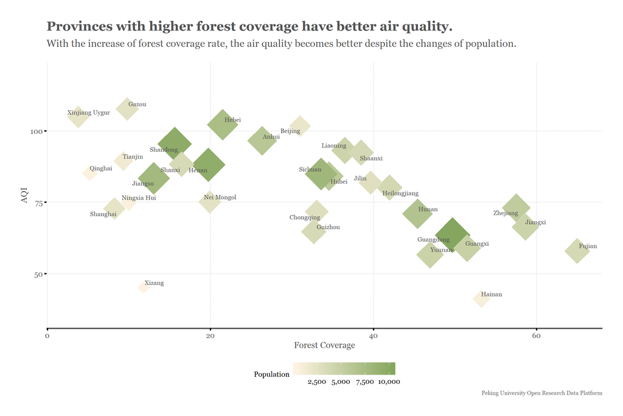

```r
p <-
    data_long %>%
    select(-("metrics")) %>%
    filter(measurement == "aqi" | measurement == "forest" | measurement == "population") %>%
    spread(measurement, value) %>%
    group_by(region) %>%
    summarise(
              aqi = mean(aqi),
              forest = mean(forest),
              population = mean(population))

g3 <-
      p %>%
      ggplot(
             aes(x = forest,
                 y = aqi,
                 color = population,
                 fill = population,
                 size = population)) +
      geom_point(shape = 23) +
      scale_color_continuous(
                             low = "#FEF3E2",
                             high = "#85A65E",
                             guide = FALSE) +
      scale_fill_continuous(
                            low = "#FEF3E2",
                            high = "#85A65E",
                            label = scales::comma) +
      scale_size_continuous(
                            range = c(6, 18),
                            guide = FALSE) +
      xlim(3, 65) +
      ylim(35, 120) +
      geom_text_repel(
                      aes(forest, aqi, label = region),
                      size = 3,
                      family = "Georgia",
                      color = "#525252") +
      theme_new() +
      theme(
           legend.key.width = unit(1 ,"cm")) +
      labs(
          title = wrapper("Provinces with higher forest coverage have better air quality.", width = 120),
          subtitle = wrapper("With the increase of forest coverage rate, the air quality becomes better despite the changes of population.", width = 140),
          caption = "Peking University Open Research Data Platform",
          x = "Forest Coverage",
          y = "AQI",
          fill = "Population")

g3
```

### Temporal Changes of Air Quality in Beijing

#### Policy Changes and Political Events

Beijing government started a series of campaigns to control the air pollution. For example, one of the largest scale projects is called “changing from coal to gas” in the winter of 2017. The air quality was largely improved after the campaign during winter times, compared to previous years. However, Beijing still has a long way to go to reduce the days above the unhealthy threshold.

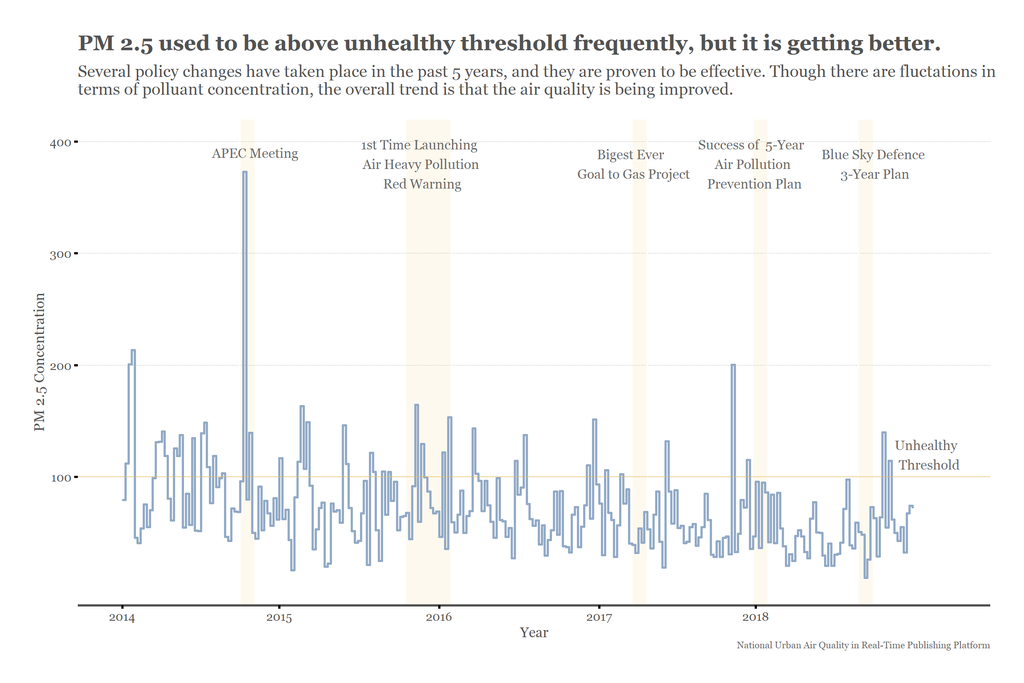

```r
g5 <-
      q %>%
      ggplot(
             aes(x = seq,
                 y = PM2.5)) +
      annotate(
              "rect",
              xmin = 40, xmax = 45, ymin = -Inf, ymax = Inf,
              color = "#FFFFFF",
              alpha = 0.1,
              fill = "#F2C057") +
      annotate(
              "rect",
              xmin = 95, xmax = 110, ymin = -Inf, ymax = Inf,
              color = "#FFFFFF",
              alpha = 0.1,
              fill = "#F2C057") +
      annotate(
              "rect",
              xmin = 170, xmax = 175, ymin = -Inf, ymax = Inf,
              color = "#FFFFFF",
              alpha = 0.1,
              fill = "#F2C057") +
      annotate(
              "rect",
              xmin = 210, xmax = 215, ymin = -Inf, ymax = Inf,
              color = "#FFFFFF",
              alpha = 0.1,
              fill = "#F2C057") +
      annotate(
              "rect",
              xmin = 245, xmax = 250, ymin = -Inf, ymax = Inf,
              color = "#FFFFFF",
              alpha = 0.1,
              fill = "#F2C057") +
      geom_step(
                size = 1,
                color = "#92AAC7") +
      scale_x_continuous(
                         limits = c(0, 275),
                         breaks = c(1, 53, 106, 159, 211),
                         labels = c("2014", "2015", "2016", "2017", "2018")) +
      scale_y_continuous(
                         limits = c(5, 400),
                         breaks = c(100, 200, 300, 400)) +
      geom_hline(
                 yintercept = 100,
                 size = 0.5,
                 color = "#F2C057",
                 alpha = 0.5) +
      annotate(
                "text",
                x = 268, y = 120,
                size = 4,
                label = "Unhealthy \n Threshold",
                family = "Georgia",
                color = "#696969") +
      annotate("text",
               x = 45, y = 390,
               size = 4,
               label = "APEC Meeting",
               family = "Georgia",
               color = "#696969") +
      annotate("text",
               x = 100, y = 380,
               size = 4,
               label = "1st Time Launching \n Air Heavy Pollution \n Red Warning",
               family = "Georgia",
               color = "#696969") +
      annotate("text",
                x = 170, y = 380,
                size = 4,
                label = "Bigest Ever \n Goal to Gas Project",
                family = "Georgia",
                color = "#696969") +
      annotate("text",
                x = 210, y = 380,
                size = 4,
                label = "Success of  5-Year \n Air Pollution \n Prevention Plan",
                family = "Georgia",
                color = "#696969") +
      annotate("text",
              x = 250, y = 380,
              size = 4,
              label = "Blue Sky Defence\n 3-Year Plan",
              family = "Georgia",
              color = "#696969") +
      theme_new() +
      theme(
            panel.grid.major.x = element_blank()) +
      labs(
          title = wrapper("PM 2.5 used to be above unhealthy threshold frequently, but it is getting better.", width = 120),
          subtitle = wrapper("Several policy changes have taken place in the past 5 years, and they are proven to be effective. Though there are fluctations in terms of polluant concentration, the overall trend is that the air quality is being improved.", width = 135),
          caption = "National Urban Air Quality in Real-Time Publishing Platform",
          x = "Year",
          y = "PM 2.5 Concentration")

g5
```

#### Year-to-Year Comparasion

Beijing lies in the northern part of China, and it is the most populated city in the country. It is also well-known for sandstorm and haze, but the local government has made efforts to mitigate the air pollution. The weekly average air quality of Beijing is improving. However, there always some terrible days in winter, as there are high demands of heating and large number of factories working towards the deadline before Lunar New Year. Plantations have been planted in the north border, which prevents wind coming from the North and take air pollutants away during the winter.

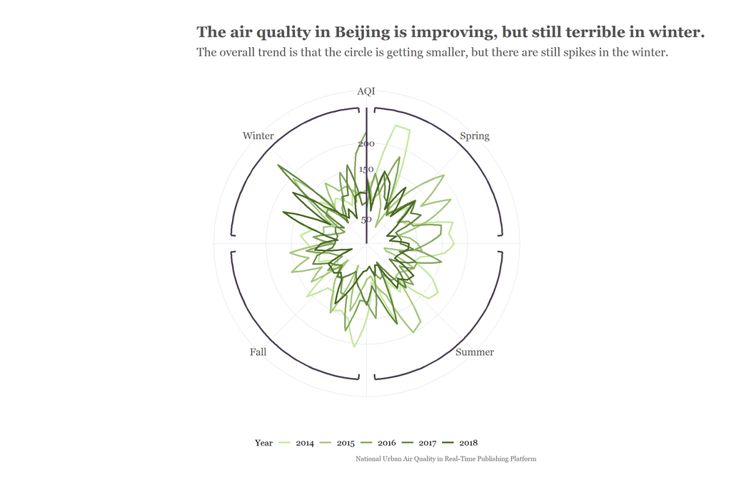

```r
g4 <-
      p %>%
      ggplot(
             aes(x = week,
                 y = AQI,
                 color = factor(year),
                 group = factor(year))) +
      geom_line(size = 1) +
      coord_polar(start = 0) +
      scale_x_continuous(
                          breaks = seq(1, 53.000001, length.out = 9),
                          labels = c("AQI", "Spring", "", "Summer", "", "Fall", "", "Winter", "")) +
      scale_y_continuous(
                          limits = c(0, 270),
                          breaks = c(0, 50, 100, 150, 200)) +
      annotate(
               "segment",
               x = 53, xend = 53, y = 0, yend = 270,
               size = 1,
               color = "#4C3F54") +
      annotate(
                "text",
                x = 53, y = 50,
                size = 4,
                label = "50",
                family = "Georgia",
                color = "#4C3F54") +
      annotate(
                "text",
                x = 53, y = 150,
                size = 4,
                label = "150",
                family = "Georgia",
                color = "#4C3F54") +
      annotate(
                "text",
                x = 53, y = 200,
                size = 4,
                label = "200",
                family = "Georgia",
                color = "#4C3F54") +
      annotate(
               "segment",
               x = 1.5, xend = 13.5, y = 270, yend = 270,
               size = 1,
               color = "#4C3F54") +
      annotate(
               "segment",
               x = 1.5, xend = 1.5, y = 260, yend = 270,
               size = 1,
               color = "#4C3F54") +
      annotate(
              "segment",
               x = 13.5, xend = 13.5, y = 260, yend = 270,
               size = 1,
               color = "#4C3F54") +
      annotate(
               "segment",
               x = 14.5, xend = 26.5, y = 270, yend = 270,
               size = 1,
               color = "#4C3F54") +
      annotate(
               "segment",
               x = 14.5, xend = 14.5, y = 260, yend = 270,
               size = 1,
               color = "#4C3F54") +
      annotate(
              "segment",
               x = 26.5, xend = 26.5, y = 260, yend = 270,
               size = 1,
               color = "#4C3F54") +
      annotate(
               "segment",
               x = 27.5, xend = 39.5, y = 270, yend = 270,
               size = 1,
               color = "#4C3F54") +
      annotate(
               "segment",
               x = 27.5, xend = 27.5, y = 260, yend = 270,
               size = 1,
               color = "#4C3F54") +
      annotate(
              "segment",
               x = 39.5, xend = 39.5, y = 260, yend = 270,
               size = 1,
               color = "#4C3F54") +
      annotate(
               "segment",
               x = 40.5, xend = 52.5, y = 270, yend = 270,
               size = 1,
               color = "#4C3F54") +
      annotate(
               "segment",
               x = 40.5, xend = 40.5, y = 260, yend = 270,
               size = 1,
               color = "#4C3F54") +
      annotate(
              "segment",
               x = 52.5, xend = 52.5, y = 260, yend = 270,
               size = 1,
               color = "#4C3F54") +
      scale_color_manual(
                         values = c("#C6E89C",
                                    "#A5C67C",
                                    "#85A65E",
                                    "#668640",
                                    "#486824")) +
      theme_new() +
      theme(
            axis.line = element_blank(),
            axis.title = element_blank(),
            axis.text.x = element_text(size = 12),
            axis.text.y = element_blank(),
            axis.ticks = element_blank(),
            plot.margin = margin(t = 30, r = 100, l = 100, b = 30, unit = "pt")) +
      labs(
            title = wrapper("The air quality in Beijing is improving, but still terrible in winter.", width = 120),
            subtitle = wrapper("The overall trend is that the circle is getting smaller, but there are still spikes in the winter.", width = 140),
            caption = "National Urban Air Quality in Real-Time Publishing Platform",
            x = "Week",
            y = "AQI",
            color = "Year")

g4
```

#### Month-to-Hour Comparasion

Breaking down by month and hour, the winter has the most serious air pollution problem. During the winter, the air quality in the mornings and evenings are worse than afternoons, partially because people need more heat before the sun comes out and after the sun comes down. Actually, it is the horrible pollution in the winter of 2016 that pushes Beijing government to launch the biggest ever “changing from coal to gas” project.

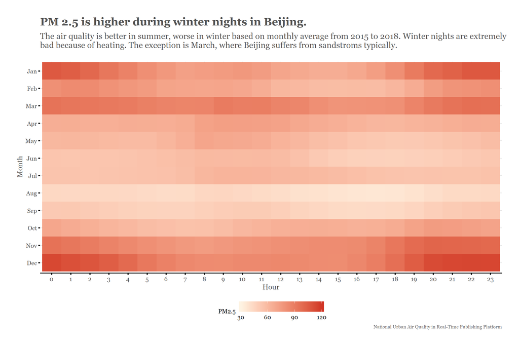

```r
a = rbind(AQI_2018, AQI_2017, AQI_2016, AQI_2015)
a$date = ymd(a$date)

g6 <-
      a %>%
      filter(metrics == "PM2.5") %>%
      group_by(bigmonth = month(date), hour) %>%
      summarise(PM2.5 = mean(value, na.rm = TRUE)) %>%
      ggplot(
            aes(x = as.factor(hour),
                y = reorder(as.factor(bigmonth), desc(as.factor(bigmonth))),
                fill = PM2.5)) +
      geom_tile() +
      scale_fill_gradient(
                          low = "#FEF3E2",
                          high = "#D13525",
                          limits = c(30, 120),
                          breaks = c(30, 60, 90, 120),
                          labels = c("30", "60", "90", "120")) +
      scale_y_discrete(labels = c("Dec", "Nov", "Oct", "Sep", "Aug", "Jul", "Jun", "May", "Apr", "Mar", "Feb", "Jan")) +
      theme_new() +
      theme(
            legend.key.width = unit(1, "cm")) +
      labs(
            title = wrapper(" PM 2.5 is higher during winter nights in Beijing.", width = 120),
            subtitle = wrapper("The air quality is better in summer, worse in winter based on monthly average from 2015 to 2018. Winter nights are extremely bad because of heating. The exception is March, where Beijing suffers from sandstroms typically.", width = 125),
            caption = "National Urban Air Quality in Real-Time Publishing Platform",
            x = "Hour",
            y = "Month")

g6
```

### Spatial Distribution of Air Quality in Beijing

#### Uneven Distribution Across Years

The distribution of air population is highly uneven in terms of districts, but things are getting better. The southern part of Beijing experienced more serious air pollution than the other parts, but the overall trend is that the air pollution is being mitigated after 2017. This observation is in consistent with the policy changes displayed above.

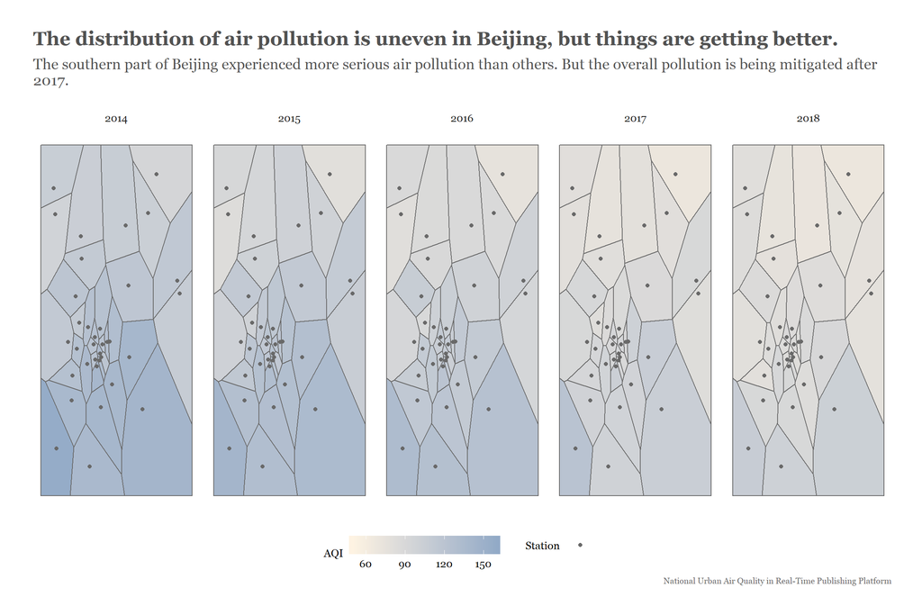

```r
g8 <-
      merged_data %>%
      ggplot(
             aes(x = lon,
                 y = lat,
                 fill = AQI)) +
      geom_voronoi(color = "#696969") +
      geom_point(
                 aes(color = "#696969"),
                 fill = "#696969") +
      scale_fill_gradient(
                          low = "#FEF3E2",
                          high = "#92AAC7",
                          limits = c(50, 160),
                          breaks = c(60, 90, 120, 150),
                          labels = c("60", "90", "120", "150")) +
      scale_colour_manual(
                          "Station",
                          values = "#696969",
                          labels = NULL) +
      facet_grid(cols = vars(year)) +
      theme_cord() +
      theme(
            legend.key.width = unit(1, "cm")) +
      guides(fill = guide_colorbar(order = 1), color = guide_legend(order = 2)) +
      labs(
            title = wrapper("The distribution of air pollution is uneven in Beijing, but things are getting better.", width = 120),
            subtitle = wrapper("The southern part of Beijing experienced more serious air pollution than others. But the overall pollution is being mitigated after 2017.", width = 135),
            caption = "National Urban Air Quality in Real-Time Publishing Platform",
            x = "Longtitude",
            y = "Latitude",
            fill = "AQI")

g8
```

#### Decomposition of Air Pollutants

The major air pollutants of Beijing are PM2.5 and PM10, as a result of burning of fossil fuels for cars, heating and factory production. Luckily, the local government has realized this issue, and has taken actions to fight against suspended particulates.

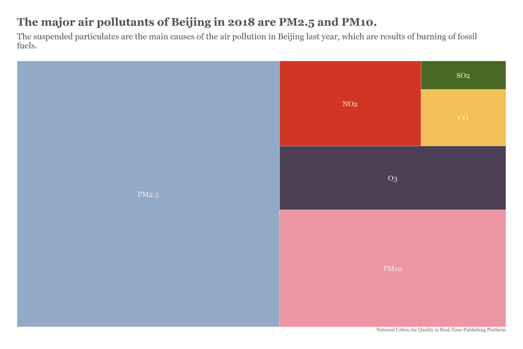

```r
g10 <-
      t %>%
      group_by(type) %>%
      summarise(value = mean(value, na.rm = TRUE)) %>%
      mutate(score = c(10, 25, 30, 55, 145, 5) / 270, group = c(1, 2, 3, 4, 4, 2)) %>%
      ggplot() +
      geom_treemap(
                   aes(area = score,
                       fill = as.factor(score)),
                   color = "#FEF3E2") +
      scale_fill_manual(
                        values  = c("#486824", "#F2C057", "#D13525", "#4C3F54","#EC96A4", "#92AAC7"),
                        guide = FALSE) +
      geom_treemap_text(
                        aes(area = score,
                            label = type),
                        place = "center",
                        size = 12,
                        colour = "#FEF3E2",
                        family = "Georgia",
                        color = "#4C3F54")  +
      theme_new() +
      labs(
            title = wrapper("The major air pollutants of Beijing in 2018 are PM2.5 and PM10.", width = 120),
            subtitle = wrapper("The suspended particulates are the main causes of the air pollution in Beijing last year, which are results of burning of fossil fuels.", width = 135),
            caption = "National Urban Air Quality in Real-Time Publishing Platform",
            area = "Pollutant",
            fill = "Contribution")
g10
```

#### Uneven Distribution of Domainant Polluants

The dominant pollutant in each district of Beijing is different. The southern part of Beijing have higher PM2.5 and PM10. The middle part have higher NO2 and S02. The northern part have higher O3. This distribution is the result of climate conditions and industry adjustment over the years. In order to reach the emission standards designed by the central government, Beijing is gradually transferring some of its responsibilities to nearby cities, including moving factories away.

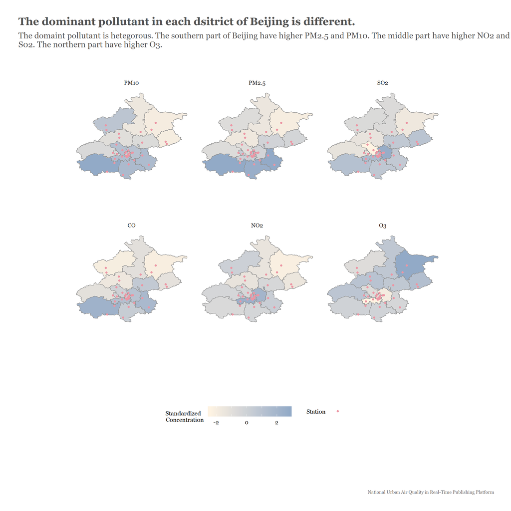

```r
g90<-
      merged_data %>%
      ggplot() +
      geom_sf(
              aes(fill = value),
              color = "#929292") +
      geom_point(
                  aes(x = lon,
                      y = lat,
                      color = "#EC96A4"),
                  fill = "#EC96A4") +
      scale_fill_gradient(
                          low = "#FEF3E2",
                          high = "#92AAC7",
                          breaks = c(-2, -1, 0, 1,2),
                          labels = c("-2", "", "0", "", "2")) +
      scale_colour_manual(
                          "Station",
                          values = "#EC96A4",
                          labels = NULL) +
      facet_grid(cols = vars(type)) +
      theme_cord() +
      theme(
            legend.key.width = unit(1, "cm")) +
      guides(fill = guide_colorbar(order = 1), color = guide_legend(order = 2)) +
      labs(
            x = "Longtitude",
            y = "Latitude",
            fill = "Standardized \n Concentration")

wantlegend = get_legend(g90)

g91<-
      merged_data %>%
      filter(type == "PM2.5" | type == "PM10" | type == "SO2") %>%
      ggplot() +
      geom_sf(
              aes(fill = value),
              color = "#929292") +
      geom_point(
                  aes(x = lon,
                      y = lat,
                      color = "#EC96A4"),
                  fill = "#EC96A4") +
      scale_fill_gradient(
                          low = "#FEF3E2",
                          high = "#92AAC7",
                          guide = FALSE) +
      scale_colour_manual(
                          "Station",
                          values = "#EC96A4",
                          labels = NULL,
                          guide = FALSE) +
      facet_grid(cols = vars(type)) +
      theme_cord()

g92<-
      merged_data %>%
      filter(type == "CO" | type == "NO2" | type == "O3") %>%
      ggplot() +
      geom_sf(
              aes(fill = value),
              color = "#929292") +
      geom_point(
                  aes(x = lon,
                      y = lat,
                      color = "#EC96A4"),
                  fill = "#EC96A4") +
      scale_fill_gradient(
                          low = "#FEF3E2",
                          high = "#92AAC7",
                          guide = FALSE) +
      scale_colour_manual(
                          "Station",
                          values = "#EC96A4",
                          labels = NULL,
                          guide = FALSE) +
      facet_grid(cols = vars(type)) +
      theme_cord()

g9 <-
      as.ggplot(plot_grid(g91, g92, wantlegend, nrow = 3)) +
      theme_cord() +
      labs(
            title = wrapper("The dominant pollutant in each dsitrict of Beijing is different.", width = 120),
            subtitle = wrapper("The domaint pollutant is hetegorous. The southern part of Beijing have higher PM2.5 and PM10. The middle part have higher NO2 and S02. The northern part have higher O3.", width = 130),
            caption = "National Urban Air Quality in Real-Time Publishing Platform")

g9
```